# 算法训练营Day 9

Author

Siru Wu

Published

January 21, 2026

## [翻转字符串里的单词](https://programmercarl.com/0151.%E7%BF%BB%E8%BD%AC%E5%AD%97%E7%AC%A6%E4%B8%B2%E9%87%8C%E7%9A%84%E5%8D%95%E8%AF%8D.html#%E7%AE%97%E6%B3%95%E5%85%AC%E5%BC%80%E8%AF%BE)

> 给你一个字符串 s ，请你反转字符串中 单词 的顺序。

> 单词 是由非空格字符组成的字符串。s 中使用至少一个空格将字符串中的 单词 分隔开。

> 返回 单词 顺序颠倒且 单词 之间用单个空格连接的结果字符串。

> 注意：输入字符串 s中可能会存在前导空格、尾随空格或者单词间的多个空格。返回的结果字符串中，单词间应当仅用单个空格分隔，且不包含任何额外的空格。

> **示例 1：**
> - 输入：s = “the sky is blue”
> - 输出：“blue is sky the”

> **示例 2：**
> - 输入：s = ” hello world ”
> - 输出：“world hello”
> - 解释：反转后的字符串中不能存在前导空格和尾随空格。

> **示例 3：**
> - 输入：s = “a good example”
> - 输出：“example good a”

> 解释：如果两个单词间有多余的空格，反转后的字符串需要将单词间的空格减少到仅有一个。

### 先删除空白，然后整个反转，最后单词反转(时间复杂度 O(n)， 空间复杂度 O(n))

```python
class Solution:
    def reverseWords(self, s: str) -> str:
        # s[::-1] 创建新字符串，然后让s重新绑定
        s = s[::-1] # 先把整个s翻转

        s = ' '.join(word[::-1] for word in s.split())

        return s
```

### 双指针法

```python
class Solution:
    def reverseWords(self, s: str) -> str:
        words = s.split()

        left, right = 0, len(words) - 1 # 这里right的长度是 len(words), 而不是 len(s)

        while right > left:
            words[left], words[right] = words[right], words[left]
            left += 1
            right -= 1

        return ' '.join(words)
```

### 拆分字符串 + 反转列表

```python
class Solution:
    def reverseWords(self, s: str) -> str:
        words = s.split()
        words = words[::-1]
        return ' '.join(words)
```

### 遇到空格就说明前面的是一个单词，把它加入到一个数组中。

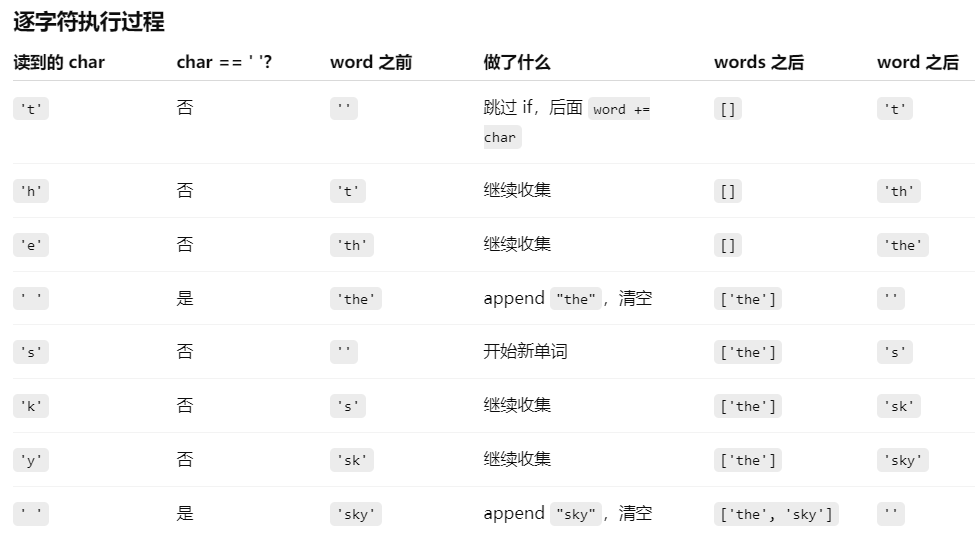

```python
class Solution:
    def reverseWords(self, s: str) -> str:
        words = []
        word = ''
        s += ' ' # 帮助处理最后一个字词

        for char in s:
            if char == ' ': # 遇到空格就说明前面的可能是一个单词
                if word != '': # 确认是单词，把它加入到一个数组中
                    words.append(word)
                    word = '' # 清空当前单词
                continue

            word += char # 收集单词的字母

        words.reverse()
        return ' '.join(words)
```